# BC Election Turnout and Competitiveness Project

authors:

- Kamal Moravej Jahromi
- Chad Neald
- Rafael Pilliard Hellwig
- Yuan Xiong

date: 28/11/2020

A group project for DSCI 522 through the Master of Data Science Program at the University of British Columbia.

## About

Are close elections correlated with higher voter turnout? This is the driving question behind our project.

We aim to determine if there is a correlation between voter turnout and the competitiveness of an election district. Specifically, we look at elections occurring in British Columbia between 2005 and 2017. To answer this question, we have used two publicly available data sets from Elections BC which “Contains information licenced under the Elections BC Open Data Licence” available [here](https://www.elections.bc.ca/docs/EBC-Open-Data-Licence.pdf) (“Elections BC Open Data Licence,” n.d.). The first data set is the [provincial voter participation](https://catalogue.data.gov.bc.ca/dataset/6d9db663-8c30-43ec-922b-d541d22e634f/resource/646530d4-078c-4815-8452-c75639962bb4) (2018a) dataset and the second is the [provincial voting results](https://catalogue.data.gov.bc.ca/dataset/44914a35-de9a-4830-ac48-870001ef8935/resource/fb40239e-b718-4a79-b18f-7a62139d9792) (2018b) dataset. These are referred to as pvp and pvr respectively throughout the project repository.

These data sets give us the opportunity to investigate the relation between the share difference in votes between the winner and the runner up and the turn out at different electoral districts for several election years. Our hypotheses are stated below:

> **Null Hypothesis:** The correlation coefficient between the voter turnout rate and the race competitiveness is equal to zero.

> **Alternative Hypothesis:** The corrrelation coefficient between the voter turnout rate and the race competitiveness is not equal to zero.

Using a Pearson correlation test we arrive at a p-value of < 0.001 which is less than our alpha value of *α* = 0.05. Our final analysis shows a positive correlation of 0.27 between voter turnout and competitiveness. Based on this information, we conclude that there is a statistically significant association between voter turnout and competitiveness for the examined elections in BC. The plot below captures the positive correlation.

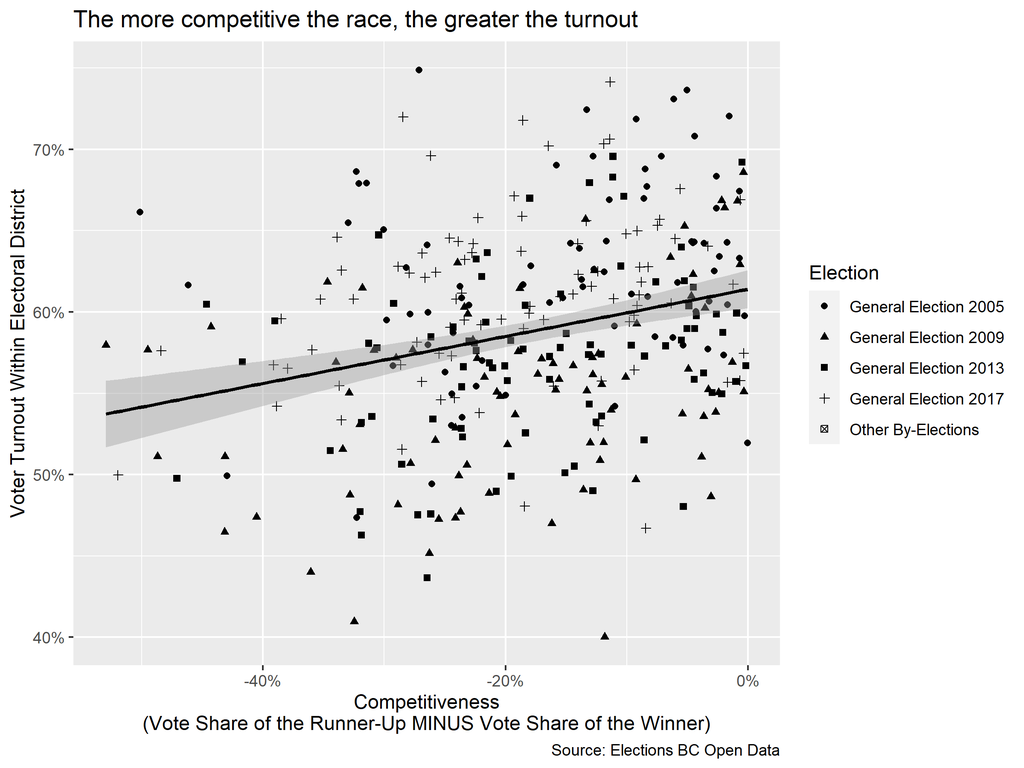

## Usage

To download the data, generate the figures, and replicate the analysis of this project you need to clone this repository and install all dependencies listed below. Once that is complete, you need to run the bc_election_turnout.sh shell script from the root of this project by executing the following from the command line:

```bash
bash bc_election_turnout.sh
```

## Dependencies

- R version 3.6.1 and R packages:
  - cowplot=1.1.0
  - dataMaid=1.4
  - docopt=0.7.1
  - GGally=2.0
  - ggpubr=0.4.0
  - ggthemes=4.2
  - here=0.1
  - janitor=2.0.1
  - tidyverse=1.3

## Report

The final report can be found here

## References

2018a. 2018. https://catalogue.data.gov.bc.ca/dataset/6d9db663-8c30-43ec-922b-d541d22e634f/resource/646530d4-078c-4815-8452-c75639962bb4.

2018b. 2018. https://catalogue.data.gov.bc.ca/dataset/44914a35-de9a-4830-ac48-870001ef8935/resource/fb40239e-b718-4a79-b18f-7a62139d9792.

“Elections BC Open Data Licence.” n.d. https://www.elections.bc.ca/docs/EBC-Open-Data-Licence.pdf.